# BI project 3

## LDA-build the model

```python
nt = 8
lda_model = gensim.models.ldamodel.LdaModel(corpus, num_topics=nt, id2word = dictionary, passes=2)

print(lda_model.print_topics(num_topics=nt, num_words=5))
```

```
[(0, '0.048*"love" + 0.022*"great" + 0.018*"perfect" + 0.015*"bought" + 0.015*"comfort"'), (1, '0.039*"great" + 0.038*"love" + 0.024*"perfect" + 0.020*"comfort" + 0.020*"leg"'), (2, '0.022*"fit" + 0.022*"beauti" + 0.018*"love" + 0.017*"look" + 0.016*"\'s"'), (3, '0.029*"size" + 0.029*"5" + 0.028*"fi…
```

```python
# Running LDA using Bag of Words
for idx, topic in lda_model.print_topics(-1):
    print('Topic: {} \nWords: {}'.format(idx, topic))
```

```
Topic: 0
Words: 0.048*"love" + 0.022*"great" + 0.018*"perfect" + 0.015*"bought" + 0.015*"comfort" + 0.015*"'s" + 0.014*"pant" + 0.014*"fit" + 0.014*"compliment" + 0.013*"purchas"
Topic: 1
Words: 0.039*"great" + 0.038*"love" + 0.024*"perfect" + 0.020*"comfort" + 0.020*"leg" + 0.019*"look" + 0.019*"fit" + 0.016*"soft" + 0.016*"pair" + 0.016*"pant"
Topic: 2
Words: 0.022*"fit" + 0.022*"beauti" + 0.018*"love" + 0.017*"look" + 0.016*"'s" + 0.013*"nice" + 0.012*"like" + 0.012*"color" + 0.011*"flatter" + 0.010*"--"
Topic: 3
Words: 0.029*"size" + 0.029*"5" + 0.028*"fit" + 0.026*"''" + 0.022*"'m" + 0.013*"small" + 0.012*"petit" + 0.012*"n't" + 0.011*"waist" + 0.010*"order"
Topic: 4
Words: 0.024*"price" + 0.022*"look" + 0.022*"like" + 0.020*"n't" + 0.020*"qualiti" + 0.016*"return" + 0.016*"review" + 0.015*"disappoint" + 0.014*"'s" + 0.014*"back"
Topic: 5
Words: 0.031*"n't" + 0.031*"look" + 0.025*"like" + 0.020*"tri" + 0.015*"would" + 0.015*"love" + 0.012*"..." + 0.011*"store" + 0.011*"'s" + 0.009*"onlin"
Topic: 6
Words: 0.028*"sleev" + 0.021*"love" + 0.018*"'s" + 0.014*"arm" + 0.014*"like" + 0.014*"look" + 0.014*"great" + 0.013*"nice" + 0.013*"littl" + 0.011*"n't"
Topic: 7
Words: 0.051*"size" + 0.031*"small" + 0.029*"run" + 0.024*"larg" + 0.020*"love" + 0.019*"cute" + 0.019*"fit" + 0.017*"order" + 0.016*"medium" + 0.015*"usual"
```

Process the output of the LDA to fit logistic regression model.

```python
score_data = pd.DataFrame(columns = ['topic_No','score'])
for i in range(0,22641):
    for score in sorted(lda_model[corpus_tfidf[i]]): #key=lambda tup: -1*tup[1]
        list = [i,score[0],score[1]]
        score_data = score_data.append({'review_index':list[0], 'topic_No':list[1], 'score':list[2]}, ignore_index=True)
score_data
```

|  | topic_No | score | review_index |
| --- | --- | --- | --- |
| 0 | 0.0 | 0.039974 | 0.0 |
| 1 | 1.0 | 0.039913 | 0.0 |
| 2 | 2.0 | 0.720950 | 0.0 |
| 3 | 3.0 | 0.039833 | 0.0 |
| 4 | 4.0 | 0.039811 | 0.0 |
| ... | ... | ... | ... |
| 181123 | 3.0 | 0.029894 | 22640.0 |
| 181124 | 4.0 | 0.029896 | 22640.0 |
| 181125 | 5.0 | 0.029906 | 22640.0 |
| 181126 | 6.0 | 0.029917 | 22640.0 |
| 181127 | 7.0 | 0.029898 | 22640.0 |

181128 rows × 3 columns

```python
score_data_new = score_data.pivot_table(
index=['review_index'],
columns=['topic_No'],
values=['score']
     )
score_data_new
```

| topic_No review_index | score 0.0 | score 1.0 | score 2.0 | score 3.0 | score 4.0 | score 5.0 | score 6.0 | score 7.0 |
| --- | --- | --- | --- | --- | --- | --- | --- | --- |
| 0.0 | 0.039974 | 0.039913 | 0.720950 | 0.039833 | 0.039811 | 0.039849 | 0.039839 | 0.039830 |
| 1.0 | 0.022221 | 0.022225 | 0.022222 | 0.409779 | 0.022207 | 0.456898 | 0.022211 | 0.022238 |
| 2.0 | 0.057676 | 0.020019 | 0.020037 | 0.312532 | 0.020067 | 0.529460 | 0.020081 | 0.020128 |
| 3.0 | 0.411090 | 0.422652 | 0.027710 | 0.027700 | 0.027741 | 0.027727 | 0.027693 | 0.027686 |
| 4.0 | 0.028789 | 0.211801 | 0.028791 | 0.028770 | 0.028753 | 0.028780 | 0.615557 | 0.028760 |
| ... | ... | ... | ... | ... | ... | ... | ... | ... |
| 22636.0 | 0.629573 | 0.029354 | 0.029381 | 0.029338 | 0.029446 | 0.029347 | 0.194241 | 0.029321 |
| 22637.0 | 0.021520 | 0.021546 | 0.021561 | 0.021537 | 0.148810 | 0.411620 | 0.331887 | 0.021518 |
| 22638.0 | 0.026998 | 0.026993 | 0.026965 | 0.026975 | 0.026960 | 0.811132 | 0.026973 | 0.027004 |
| 22639.0 | 0.019665 | 0.214569 | 0.019655 | 0.019692 | 0.298844 | 0.388194 | 0.019646 | 0.019734 |
| 22640.0 | 0.790611 | 0.029943 | 0.029934 | 0.029894 | 0.029896 | 0.029906 | 0.029917 | 0.029898 |

22641 rows × 8 columns

```python
columns = []
for i in range(0,nt):
    cl_name = 'topic_'+str(i)
    columns.append(cl_name)

columns
```

```
['topic_0',
 'topic_1',
 'topic_2',
 'topic_3',
 'topic_4',
 'topic_5',
 'topic_6',
 'topic_7']
```

```python
score_table = pd.DataFrame(score_data_new.values,columns = columns)
score_table
```

|  | topic_0 | topic_1 | topic_2 | topic_3 | topic_4 | topic_5 | topic_6 | topic_7 |
| --- | --- | --- | --- | --- | --- | --- | --- | --- |
| 0 | 0.039974 | 0.039913 | 0.720950 | 0.039833 | 0.039811 | 0.039849 | 0.039839 | 0.039830 |
| 1 | 0.022221 | 0.022225 | 0.022222 | 0.409779 | 0.022207 | 0.456898 | 0.022211 | 0.022238 |
| 2 | 0.057676 | 0.020019 | 0.020037 | 0.312532 | 0.020067 | 0.529460 | 0.020081 | 0.020128 |
| 3 | 0.411090 | 0.422652 | 0.027710 | 0.027700 | 0.027741 | 0.027727 | 0.027693 | 0.027686 |
| 4 | 0.028789 | 0.211801 | 0.028791 | 0.028770 | 0.028753 | 0.028780 | 0.615557 | 0.028760 |
| ... | ... | ... | ... | ... | ... | ... | ... | ... |
| 22636 | 0.629573 | 0.029354 | 0.029381 | 0.029338 | 0.029446 | 0.029347 | 0.194241 | 0.029321 |
| 22637 | 0.021520 | 0.021546 | 0.021561 | 0.021537 | 0.148810 | 0.411620 | 0.331887 | 0.021518 |
| 22638 | 0.026998 | 0.026993 | 0.026965 | 0.026975 | 0.026960 | 0.811132 | 0.026973 | 0.027004 |
| 22639 | 0.019665 | 0.214569 | 0.019655 | 0.019692 | 0.298844 | 0.388194 | 0.019646 | 0.019734 |
| 22640 | 0.790611 | 0.029943 | 0.029934 | 0.029894 | 0.029896 | 0.029906 | 0.029917 | 0.029898 |

22641 rows × 8 columns

## LDA-Predict sentiment (Recommended / Not recommended)

Logistic regression and calculate the prediction error

```python
from sklearn.model_selection import train_test_split
from sklearn.linear_model import LogisticRegression
from sklearn.metrics import accuracy_score
from sklearn import preprocessing

from sklearn.ensemble import RandomForestClassifier
from sklearn.svm import LinearSVC
from sklearn.feature_extraction.text import TfidfTransformer
from sklearn.naive_bayes import MultinomialNB
from sklearn.metrics import classification_report

X = score_table
y = df["Recommended IND"]
```

```python
X_train, X_test, y_train, y_test = train_test_split(X, y, test_size = 0.20, random_state = 0)

scaler = preprocessing.MinMaxScaler()
X_train_scaled = scaler.fit_transform(X_train)
X_test_scaled = scaler.transform(X_test)
```

```python
# logistic regression
lr = LogisticRegression()
lr.fit(X_train_scaled,y_train)
y_pred = lr.predict(X_test_scaled)
print("accuracy_score:",accuracy_score(y_test, y_pred))
```

```
accuracy_score: 0.8275557518215941
```

```python
print("Classification Report:\n ", classification_report(y_test, y_pred))
```

```
Classification Report:
                precision    recall  f1-score   support

           0       0.65      0.24      0.35       877
           1       0.84      0.97      0.90      3652

    accuracy                           0.83      4529
   macro avg       0.74      0.61      0.63      4529
weighted avg       0.80      0.83      0.79      4529
```

RandomForestClassfier and calculate the prediction error

```python
# RandomForestClassfier
ran = RandomForestClassifier(n_estimators=50)
ran.fit(X_train, y_train)
y_pred2 = ran.predict(X_test)
print("accuracy_score:",accuracy_score(y_test, y_pred2))
```

```
accuracy_score: 0.8085670125855597
```

```python
print("Classification Report:\n ", classification_report(y_test, y_pred2))
```

```
Classification Report:
                precision    recall  f1-score   support

           0       0.51      0.28      0.36       877
           1       0.84      0.94      0.89      3652

    accuracy                           0.81      4529
   macro avg       0.68      0.61      0.63      4529
weighted avg       0.78      0.81      0.79      4529
```

Naive Bayes and calculate the prediction error

```python
# Naive Bayes
classifier = MultinomialNB()
classifier.fit(X_train, y_train)
y_pred3 = classifier.predict(X_test)
print("accuracy_score:",accuracy_score(y_test, y_pred3))
```

```
accuracy_score: 0.8063590196511371
```

```python
print("Classification Report:\n ", classification_report(y_test, y_pred3))
```

```
Classification Report:
                precision    recall  f1-score   support

           0       0.00      0.00      0.00       877
           1       0.81      1.00      0.89      3652

    accuracy                           0.81      4529
   macro avg       0.40      0.50      0.45      4529
weighted avg       0.65      0.81      0.72      4529
```

# LSA-choose the topic number

```python
from gensim.models import LsiModel
```

```python
def compute_coherence_values(dictionary, doc_term_matrix, doc_clean, stop, start=2, step=3): #def2
    """
    Input   : dictionary : Gensim dictionary
              corpus : Gensim corpus
              texts : List of input texts
              stop : Max num of topics
    purpose : Compute c_v coherence for various number of topics
    Output  : model_list : List of LSA topic models
              coherence_values : Coherence values corresponding to the LDA model with respective number of topics
    """
    coherence_values = []
    model_list = []
    for num_of_topics in range(start, stop, step):
        # generate LSA model
        print(num_of_topics)
        model = LsiModel(doc_term_matrix, num_topics=num_of_topics, id2word = dictionary)  # train model
        model_list.append(model)
        coherencemodel = CoherenceModel(model=model, texts=texts, dictionary=dictionary, coherence='c_v')
        coherence_values.append(coherencemodel.get_coherence())
        print(coherence_values)
    return model_list, coherence_values
```

```python
def plot_graph(doc_clean,start, stop, step): #def3
    #dictionary
    model_list, coherence_values = compute_coherence_values(dictionary, corpus,texts,stop, start, step) #def2
    # Show graph
    x = range(start, stop, step)
    plt.plot(x, coherence_values)
    plt.xlabel("Number of Topics")
    plt.ylabel("Coherence score")
    plt.legend(("coherence_values"), loc='best')
    plt.show()
```

[output not shown]

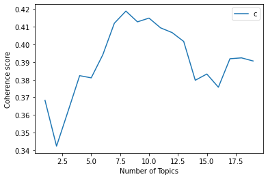

```python
start,stop,step=1,20,1
plot_graph(texts,start,stop,step)
print()
# We got 8 is the optimal number for the topic choosen.
```

## LSA-build the model

```python
nt = 8
lsa_model = LsiModel(corpus, num_topics=nt, id2word = dictionary)

print(lsa_model.print_topics(num_topics=nt, num_words=5))
```

```
[(0, '0.322*"love" + 0.313*"fit" + 0.302*"size" + 0.237*"look" + 0.218*"n\'t"'), (1, '-0.622*"size" + 0.613*"love" + -0.192*"fit" + 0.169*"look" + -0.153*"small"'), (2, '0.594*"love" + -0.463*"look" + -0.357*"like" + 0.314*"size" + -0.258*"n\'t"'), (3, '-0.722*"fit" + 0.383*"size" + -0.313*"great" +…
```

```python
# Running LSA using Bag of Words
for idx, topic in lsa_model.print_topics(-1):
    print('Topic: {} \nWords: {}'.format(idx, topic))
```

```
Topic: 0
Words: 0.322*"love" + 0.313*"fit" + 0.302*"size" + 0.237*"look" + 0.218*"n't" + 0.204*"'s" + 0.202*"like" + 0.170*"great" + 0.157*"'m" + 0.137*"would"
Topic: 1
Words: -0.622*"size" + 0.613*"love" + -0.192*"fit" + 0.169*"look" + -0.153*"small" + 0.133*"great" + 0.110*"'s" + -0.088*"order" + -0.086*"5" + -0.084*"run"
Topic: 2
Words: 0.594*"love" + -0.463*"look" + -0.357*"like" + 0.314*"size" + -0.258*"n't" + -0.157*"'s" + 0.143*"fit" + -0.083*"realli" + -0.082*"would" + 0.077*"perfect"
Topic: 3
Words: -0.722*"fit" + 0.383*"size" + -0.313*"great" + 0.203*"'s" + 0.195*"love" + 0.167*"n't" + -0.115*"5" + 0.103*"run" + -0.098*"''" + -0.084*"perfect"
Topic: 4
Words: 0.707*"'s" + -0.484*"look" + 0.249*"'m" + -0.203*"size" + -0.200*"like" + -0.157*"love" + 0.123*"n't" + 0.121*"5" + 0.115*"''" + 0.084*"perfect"
Topic: 5
Words: -0.565*"great" + 0.490*"n't" + -0.319*"'s" + -0.311*"look" + 0.233*"fit" + -0.211*"size" + 0.132*"love" + 0.131*"like" + 0.120*"would" + 0.093*"tri"
Topic: 6
Words: 0.472*"5" + 0.472*"''" + -0.342*"fit" + 0.325*"'m" + -0.263*"'s" + -0.195*"n't" + -0.192*"size" + 0.178*"small" + 0.121*"petit" + 0.103*"look"
Topic: 7
Words: -0.571*"n't" + -0.537*"great" + 0.354*"like" + 0.291*"'s" + 0.217*"fit" + 0.154*"look" + 0.149*"love" + -0.094*"work" + -0.079*"pant" + -0.075*"ca"
```

```python
score_data2 = pd.DataFrame(columns = ['topic_No','score'])
for i in range(0,22641):
    for score in sorted(lsa_model[corpus_tfidf[i]]): #key=lambda tup: -1*tup[1]
        list = [i,score[0],score[1]]
        score_data2 = score_data2.append({'review_index':list[0], 'topic_No':list[1], 'score':list[2]}, ignore_index=True)
score_data2
```

|  | topic_No | score | review_index |
| --- | --- | --- | --- |
| 0 | 0.0 | 0.033416 | 0.0 |
| 1 | 1.0 | 0.022106 | 0.0 |
| 2 | 2.0 | 0.012245 | 0.0 |
| 3 | 3.0 | -0.009884 | 0.0 |
| 4 | 4.0 | 0.010904 | 0.0 |
| ... | ... | ... | ... |
| 181123 | 3.0 | -0.058496 | 22640.0 |
| 181124 | 4.0 | -0.038867 | 22640.0 |
| 181125 | 5.0 | 0.039531 | 22640.0 |
| 181126 | 6.0 | -0.055864 | 22640.0 |
| 181127 | 7.0 | 0.075451 | 22640.0 |

181128 rows × 3 columns

```python
score_data_new2 = score_data2.pivot_table(
index=['review_index'],
columns=['topic_No'],
values=['score']
     )
score_data_new2
```

| topic_No review_index | score 0.0 | score 1.0 | score 2.0 | score 3.0 | score 4.0 | score 5.0 | score 6.0 | score 7.0 |
| --- | --- | --- | --- | --- | --- | --- | --- | --- |
| 0.0 | 0.033416 | 0.022106 | 0.012245 | -0.009884 | 0.010904 | -0.013005 | -0.005899 | -0.001580 |
| 1.0 | 0.194983 | 0.000109 | 0.013663 | 0.038365 | 0.113181 | 0.005767 | 0.127598 | 0.022043 |
| 2.0 | 0.119769 | -0.062389 | 0.004922 | 0.006079 | -0.003516 | 0.019823 | 0.026059 | -0.013170 |
| 3.0 | 0.145619 | 0.161157 | 0.104547 | 0.029380 | 0.052163 | -0.068091 | -0.031986 | -0.020804 |
| 4.0 | 0.120345 | 0.071890 | 0.043576 | -0.040361 | 0.012634 | -0.003333 | 0.023955 | -0.019893 |
| ... | ... | ... | ... | ... | ... | ... | ... | ... |
| 22636.0 | 0.110180 | 0.063789 | -0.014309 | -0.049548 | 0.087167 | -0.157440 | -0.046774 | -0.102124 |
| 22637.0 | 0.133175 | 0.035009 | -0.074368 | 0.002098 | -0.027831 | -0.010490 | 0.003105 | 0.002809 |
| 22638.0 | 0.243090 | -0.008009 | -0.076011 | -0.029998 | 0.022995 | 0.083487 | -0.013436 | -0.184564 |
| 22639.0 | 0.201113 | 0.002850 | -0.065918 | -0.032679 | 0.041039 | 0.019982 | -0.026274 | 0.002965 |
| 22640.0 | 0.155183 | 0.055712 | 0.019507 | -0.058496 | -0.038867 | 0.039531 | -0.055864 | 0.075451 |

22641 rows × 8 columns

```python
columns = []
for i in range(0,8):
    cl_name = 'topic_'+str(i)
    columns.append(cl_name)

columns
```

```
['topic_0',
 'topic_1',
 'topic_2',
 'topic_3',
 'topic_4',
 'topic_5',
 'topic_6',
 'topic_7']
```

```python
score_table2 = pd.DataFrame(score_data_new2.values,columns = columns)
score_table2
```

|  | topic_0 | topic_1 | topic_2 | topic_3 | topic_4 | topic_5 | topic_6 | topic_7 |
| --- | --- | --- | --- | --- | --- | --- | --- | --- |
| 0 | 0.033416 | 0.022106 | 0.012245 | -0.009884 | 0.010904 | -0.013005 | -0.005899 | -0.001580 |
| 1 | 0.194983 | 0.000109 | 0.013663 | 0.038365 | 0.113181 | 0.005767 | 0.127598 | 0.022043 |
| 2 | 0.119769 | -0.062389 | 0.004922 | 0.006079 | -0.003516 | 0.019823 | 0.026059 | -0.013170 |
| 3 | 0.145619 | 0.161157 | 0.104547 | 0.029380 | 0.052163 | -0.068091 | -0.031986 | -0.020804 |
| 4 | 0.120345 | 0.071890 | 0.043576 | -0.040361 | 0.012634 | -0.003333 | 0.023955 | -0.019893 |
| ... | ... | ... | ... | ... | ... | ... | ... | ... |
| 22636 | 0.110180 | 0.063789 | -0.014309 | -0.049548 | 0.087167 | -0.157440 | -0.046774 | -0.102124 |
| 22637 | 0.133175 | 0.035009 | -0.074368 | 0.002098 | -0.027831 | -0.010490 | 0.003105 | 0.002809 |
| 22638 | 0.243090 | -0.008009 | -0.076011 | -0.029998 | 0.022995 | 0.083487 | -0.013436 | -0.184564 |
| 22639 | 0.201113 | 0.002850 | -0.065918 | -0.032679 | 0.041039 | 0.019982 | -0.026274 | 0.002965 |
| 22640 | 0.155183 | 0.055712 | 0.019507 | -0.058496 | -0.038867 | 0.039531 | -0.055864 | 0.075451 |

22641 rows × 8 columns

## LSA-Predict sentiment (Recommended / Not recommended)

```python
from sklearn.model_selection import train_test_split
from sklearn.linear_model import LogisticRegression
from sklearn.metrics import accuracy_score
from sklearn import preprocessing

from sklearn.ensemble import RandomForestClassifier
from sklearn.svm import LinearSVC
from sklearn.feature_extraction.text import TfidfTransformer
from sklearn.naive_bayes import MultinomialNB
from sklearn.metrics import classification_report

X = score_table2
y = df["Recommended IND"]
```

```python
X_train, X_test, y_train, y_test = train_test_split(X, y, test_size = 0.20, random_state = 0)

scaler = preprocessing.MinMaxScaler()
X_train_scaled = scaler.fit_transform(X_train)
X_test_scaled = scaler.transform(X_test)
```

logistic regression and calculate the prediction error

```python
# logistic regression
lr = LogisticRegression()
lr.fit(X_train_scaled,y_train)
y_pred = lr.predict(X_test_scaled)
accuracy_score(y_test, y_pred)
```

```
0.8180613822035769
```

```python
print("Classification Report:\n ", classification_report(y_test, y_pred))
```

```
Classification Report:
                precision    recall  f1-score   support

           0       0.63      0.15      0.24       877
           1       0.83      0.98      0.90      3652

    accuracy                           0.82      4529
   macro avg       0.73      0.56      0.57      4529
weighted avg       0.79      0.82      0.77      4529
```

RandomForestClassfier and calculate the prediction error

```python
# RandomForestClassfier
ran = RandomForestClassifier()
ran.fit(X_train_scaled, y_train)
y_pred2 = ran.predict(X_test)
accuracy_score(y_test, y_pred2)
```

```
0.8063590196511371
```

```python
print("Classification Report:\n ", classification_report(y_test, y_pred2))
```

```
Classification Report:
                precision    recall  f1-score   support

           0       0.00      0.00      0.00       877
           1       0.81      1.00      0.89      3652

    accuracy                           0.81      4529
   macro avg       0.40      0.50      0.45      4529
weighted avg       0.65      0.81      0.72      4529
```

Naive Bayes and calculate the prediction error

```python
# Naive Bayes
classifier = MultinomialNB()
classifier.fit(X_train_scaled, y_train)
y_pred3 = classifier.predict(X_test)
accuracy_score(y_test, y_pred3)
```

```
0.8063590196511371
```

```python
print("Classification Report:\n ", classification_report(y_test, y_pred3))
```

```
Classification Report:
                precision    recall  f1-score   support

           0       0.00      0.00      0.00       877
           1       0.81      1.00      0.89      3652

    accuracy                           0.81      4529
   macro avg       0.40      0.50      0.45      4529
weighted avg       0.65      0.81      0.72      4529
```

## (BONUS. NOT required) Cross validation

Implement the cross validation algorithm during your model training to select the topic number in a LSA/LDA model.

We write the cross validation codes, but we have no computer resources to run out the outcome.

```python
data = {'review':documents}
df=pd.DataFrame(data)

#move english_punctuations
def punctuation_removal(messy_str):
    clean_list = [word for word in messy_str if word not in string.punctuation]
    clean_str = ''.join(clean_list)
    return clean_str

df['review'] = df['review'].apply(punctuation_removal)
df['review'].head()

#text tokenized and transformed to lowercase,move stop_words
stop_words = []
stop = stopwords.words('english')

for item in stop:
    new_item = punctuation_removal(item)
    stop_words.append(new_item)
print(stop_words)

def texts_filtered_stopwords(messy_str):
    messy_str = word_tokenize(messy_str)
    return [word.lower() for word in messy_str
            if word.lower() not in stop_words]

df['review'] = df['review'].apply(texts_filtered_stopwords)
df['review'].head()

stemmer = PorterStemmer()

def texts_stemmed(text_list):
    text_list_new = []
    for word in text_list:
        word = stemmer.stem(word)
        text_list_new.append(word)
    return text_list_new

df['review'] = df['review'].apply(texts_stemmed)
df['review'].head()

df['review'] = df['review'].apply(lambda x: ' '.join(x))
df['review'].head()
```

```python
from sklearn.feature_extraction.text import CountVectorizer
from sklearn.feature_extraction.text import TfidfTransformer

def text_vectorizing_process(sentence_string):
    return [word for word in sentence_string.split()]

bow_transformer = CountVectorizer(text_vectorizing_process)
bow_transformer.fit(df['review'])

Reviews = bow_transformer.transform(df['review'])
```

```python
from sklearn.decomposition import LatentDirichletAllocation
from sklearn.model_selection import GridSearchCV

param_test = {'n_components': [5, 10, 15]}
grid_search = GridSearchCV(estimator=LatentDirichletAllocation(learning_method='batch',max_iter=100,n_jobs=-1,verbose=1),param_grid=param_test,cv=3, n_jobs=-1)
grid_result=grid_search.fit(Reviews)
```